# Laboratorio 6

## 6. Detección de comunidades (Louvain)

```python
try:
    from community import community_louvain
except Exception:
    import community as community_louvain


if community_louvain:
    undirected = G.to_undirected()
    partition = community_louvain.best_partition(undirected, random_state=42)
    nx.set_node_attributes(G, partition, 'community')
    # Tamaños por comunidad
    counter = collections.Counter(partition.values())
    comm_sizes = pd.DataFrame(counter.items(), columns=['community','size']).sort_values('size', ascending=False)
    display(comm_sizes)
else:
    partition = {}
    comm_sizes = pd.DataFrame(columns=['community','size'])
```

|  | community | size |
| --- | --- | --- |
| 4 | 5 | 930 |
| 8 | 9 | 340 |
| 0 | 0 | 325 |
| 9 | 11 | 188 |
| 2 | 3 | 185 |
| 10 | 12 | 185 |
| 1 | 2 | 176 |
| 11 | 19 | 165 |
| 7 | 8 | 147 |
| 5 | 6 | 136 |
| 3 | 4 | 99 |
| 6 | 1 | 79 |
| 12 | 17 | 71 |
| 14 | 10 | 52 |
| 18 | 14 | 9 |
| 16 | 7 | 8 |
| 19 | 15 | 3 |
| 13 | 16 | 2 |
| 15 | 18 | 2 |
| 17 | 13 | 2 |

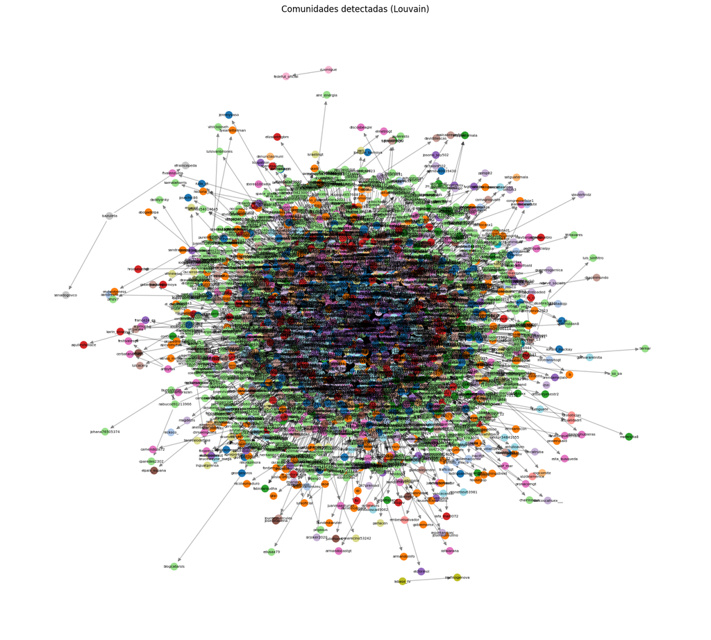

```python
# Visualización coloreada por comunidad
if community_louvain and len(G) > 0:
    plt.figure(figsize=(18,16))
    pos = nx.spring_layout(G, seed=42)
    comms = [G.nodes[n].get('community', -1) for n in G.nodes()]
    nx.draw_networkx_nodes(G, pos, node_color=comms, node_size=100, cmap='tab20')
    nx.draw_networkx_edges(G, pos, arrows=True, alpha=0.3)
    nx.draw_networkx_labels(G, pos, font_size=5)
    plt.title('Comunidades detectadas (Louvain)')
    plt.axis('off')
    plt.show()
```

### 6.2. Gráfico de las 3 comunidades más grandes

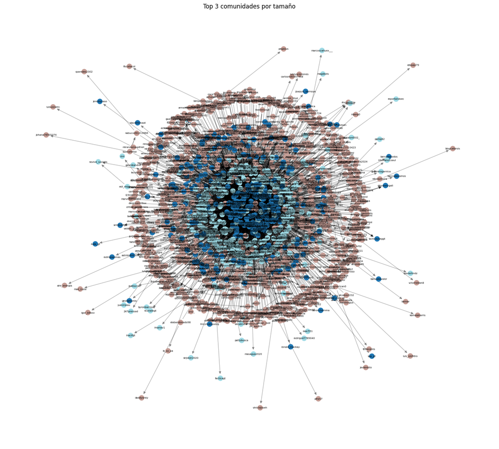

```python
# grafico de las 3 comunidades mas grandes
if not comm_sizes.empty:
    top3_ids = comm_sizes.head(3)['community'].tolist()
    subset_nodes = [n for n, d in G.nodes(data=True) if d.get('community') in top3_ids]
    H = G.subgraph(subset_nodes)
    plt.figure(figsize=(18,16))
    pos = nx.spring_layout(H, seed=42)
    comms = [H.nodes[n].get('community', -1) for n in H.nodes()]
    nx.draw_networkx_nodes(H, pos, node_color=comms, node_size=100, cmap='tab20')
    nx.draw_networkx_edges(H, pos, arrows=True, alpha=0.3)
    nx.draw_networkx_labels(H, pos, font_size=5)
    plt.title('Top 3 comunidades por tamaño')
    plt.axis('off')
    plt.show()
```

Se puede observar que son 20 comunidades y que la comunidad más grande es la 5 con 930 nodos, probablemente es el grupo en donde se concentra la mayor parte de menciones a la cuenta de Bernardo, los cuales podrian ser medios de comunicación a fines y usuarios que interactúan entre sí. Luego está la comunidad 9 con 340 nodos y la comunidad 0 con 325 nodos. Ambos son bastante grandes, estos puede que sean críticos que mencionan o retuitean entre sí, o también grupos de medios digitales, periodistas que interactúan acerca del tema o incluso podrían ser comunidades de fans o haters.

Por otra parte hay comunidades medianas, las cuales tienen entre 100 a 200 nodos, que se muestran como clusters especializados. Estos probablemente sean agrupaciones tematicas como de economía, ONGs, grupos de una región en especifíco o cuentas automatizadas.

Mientras, las comunidades pequeñas menores de 20, parecen islas, en las que puede que las cuentas sean grupos de cuentas muy cerradas, bots coordinados o usuarios eventuales que no se integraron al debate general.

Hay varias comunidades y la conversación parece que no es muy uniforme ya que hay varios clusters medianos que presentan otra narrativa, pueden ser oposiciones o comunidades e interés.